# AIML_ML_Project_full_code_notebook

#### Decision Tree (Post-pruning)

- Cost complexity pruning provides another option to control the size of a tree.
- In `DecisionTreeClassifier`, this pruning technique is parameterized by the cost complexity parameter, `ccp_alpha`.
- Greater values of `ccp_alpha` increase the number of nodes pruned.
- Here we only show the effect of `ccp_alpha` on regularizing the trees and how to choose the optimal `ccp_alpha` value.

**Total impurity of leaves vs effective alphas of pruned tree**

Minimal cost complexity pruning recursively finds the node with the "weakest link". The weakest link is characterized by an effective alpha, where the nodes with the smallest effective alpha are pruned first. To get an idea of what values of `ccp_alpha` could be appropriate, scikit-learn provides `DecisionTreeClassifier.cost_complexity_pruning_path` that returns the effective alphas and the corresponding total leaf impurities at each step of the pruning process. As alpha increases, more of the tree is pruned, which increases the total impurity of its leaves.

```python
clf = DecisionTreeClassifier(random_state=1, class_weight="balanced")
path = clf.cost_complexity_pruning_path(X_train, y_train)
ccp_alphas, impurities = abs(path.ccp_alphas), path.impurities
```

```python
pd.DataFrame(path)
```

|  | ccp_alphas | impurities |
| --- | --- | --- |
| 0 | 0.000000e+00 | -7.995347e-15 |
| 1 | 3.853725e-19 | -7.994961e-15 |
| 2 | 3.853725e-19 | -7.994576e-15 |
| 3 | 4.729571e-19 | -7.994103e-15 |
| 4 | 5.255079e-19 | -7.993578e-15 |
| 5 | 5.255079e-19 | -7.993052e-15 |
| 6 | 5.255079e-19 | -7.992527e-15 |
| 7 | 7.006772e-19 | -7.991826e-15 |
| 8 | 1.051016e-18 | -7.990775e-15 |
| 9 | 1.576524e-18 | -7.989198e-15 |
| 10 | 1.257806e-17 | -7.976620e-15 |
| 11 | 1.524700e-04 | 3.049400e-04 |
| 12 | 1.567552e-04 | 6.184504e-04 |
| 13 | 2.761014e-04 | 1.170653e-03 |
| 14 | 2.857143e-04 | 1.456367e-03 |
| 15 | 2.998950e-04 | 2.056158e-03 |
| 16 | 3.049400e-04 | 2.666038e-03 |
| 17 | 4.498426e-04 | 3.565723e-03 |
| 18 | 4.714887e-04 | 5.451677e-03 |
| 19 | 5.430671e-04 | 5.994745e-03 |
| 20 | 5.517639e-04 | 6.546508e-03 |
| 21 | 5.835652e-04 | 7.713639e-03 |
| 22 | 5.900285e-04 | 8.303667e-03 |
| 23 | 6.292497e-04 | 9.562167e-03 |
| 24 | 6.380903e-04 | 1.275262e-02 |
| 25 | 6.616439e-04 | 1.407591e-02 |
| 26 | 7.538167e-04 | 1.482972e-02 |
| 27 | 7.580649e-04 | 1.634585e-02 |
| 28 | 8.981804e-04 | 1.724403e-02 |
| 29 | 9.269294e-04 | 1.817096e-02 |
| 30 | 1.461815e-03 | 1.963278e-02 |
| 31 | 1.671123e-03 | 2.130390e-02 |
| 32 | 1.768018e-03 | 2.307192e-02 |
| 33 | 2.221376e-03 | 2.751467e-02 |
| 34 | 2.375809e-03 | 2.989048e-02 |
| 35 | 2.472660e-03 | 3.483580e-02 |
| 36 | 3.297255e-03 | 3.813305e-02 |
| 37 | 3.344493e-03 | 4.147755e-02 |
| 38 | 3.503794e-03 | 4.498134e-02 |
| 39 | 3.602932e-03 | 5.218720e-02 |
| 40 | 3.729690e-03 | 5.591689e-02 |
| 41 | 4.941457e-03 | 6.085835e-02 |
| 42 | 4.970987e-03 | 7.080032e-02 |
| 43 | 2.255792e-02 | 9.335825e-02 |
| 44 | 3.708749e-02 | 2.046207e-01 |
| 45 | 2.953793e-01 | 5.000000e-01 |

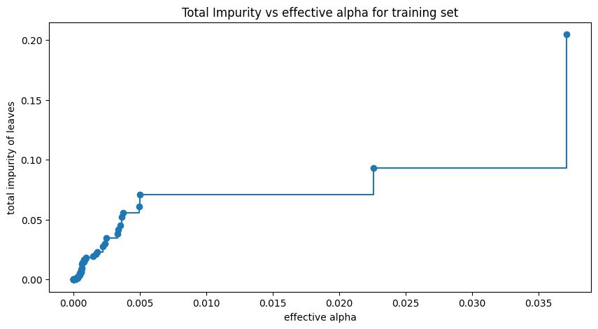

```python
fig, ax = plt.subplots(figsize=(10, 5))
ax.plot(ccp_alphas[:-1], impurities[:-1], marker="o", drawstyle="steps-post")
ax.set_xlabel("effective alpha")
ax.set_ylabel("total impurity of leaves")
ax.set_title("Total Impurity vs effective alpha for training set")
plt.show()
```

Next, we train a decision tree using the effective alphas. The last value in `ccp_alphas` is the alpha value that prunes the whole tree, leaving the tree, `clfs[-1]`, with one node.

```python
clfs = []
for ccp_alpha in ccp_alphas:
    clf = DecisionTreeClassifier(
        random_state=1, ccp_alpha=ccp_alpha, class_weight="balanced"
    )
    clf.fit(X_train, y_train)
    clfs.append(clf)
print(
    "Number of nodes in the last tree is: {} with ccp_alpha: {}".format(
        clfs[-1].tree_.node_count, ccp_alphas[-1]
    )
)
```

```
Number of nodes in the last tree is: 1 with ccp_alpha: 0.29537927599923164
```

For the remainder, we remove the last element in `clfs` and `ccp_alphas`, because it is the trivial tree with only one node. Here we show that the number of nodes and tree depth decreases as alpha increases.

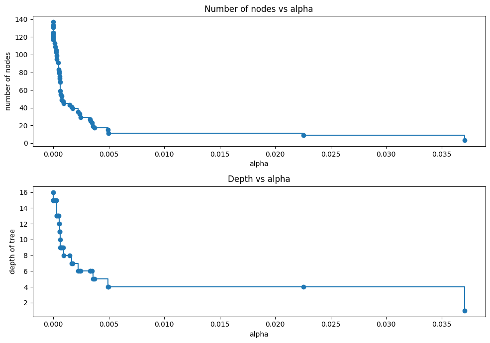

```python
clfs = clfs[:-1]
ccp_alphas = ccp_alphas[:-1]

node_counts = [clf.tree_.node_count for clf in clfs]
depth = [clf.tree_.max_depth for clf in clfs]
fig, ax = plt.subplots(2, 1, figsize=(10, 7))
ax[0].plot(ccp_alphas, node_counts, marker="o", drawstyle="steps-post")
ax[0].set_xlabel("alpha")
ax[0].set_ylabel("number of nodes")
ax[0].set_title("Number of nodes vs alpha")
ax[1].plot(ccp_alphas, depth, marker="o", drawstyle="steps-post")
ax[1].set_xlabel("alpha")
ax[1].set_ylabel("depth of tree")
ax[1].set_title("Depth vs alpha")
fig.tight_layout()
```

**Recall vs alpha for training and testing sets**

```python
recall_train = []
for clf in clfs:
    pred_train = clf.predict(X_train)
    values_train = recall_score(y_train, pred_train)
    recall_train.append(values_train)

recall_test = []
for clf in clfs:
    pred_test = clf.predict(X_test)
    values_test = recall_score(y_test, pred_test)
    recall_test.append(values_test)
```

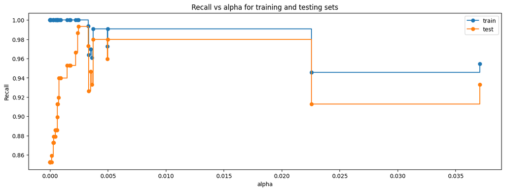

```python
fig, ax = plt.subplots(figsize=(15, 5))
ax.set_xlabel("alpha")
ax.set_ylabel("Recall")
ax.set_title("Recall vs alpha for training and testing sets")
ax.plot(ccp_alphas, recall_train, marker="o", label="train", drawstyle="steps-post")
ax.plot(ccp_alphas, recall_test, marker="o", label="test", drawstyle="steps-post")
ax.legend()
plt.show()
```

```python
# creating the model where we get highest train and test recall
index_best_model = np.argmax(recall_test)
best_model = clfs[index_best_model]
print(best_model)
```

```
DecisionTreeClassifier(ccp_alpha=0.0024726598786421854, class_weight='balanced',
                       random_state=1)
```

Above is the best performing decision tree model selected based on the highest test recall.

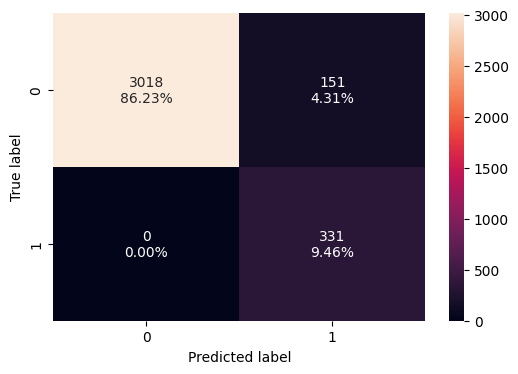

```python
# Initialize the best model
dt_post_pruned = best_model

# Confusion matrix on training set
confusion_matrix_sklearn(dt_post_pruned, X_train, y_train)
```

```python
# Model performance on training set
dt_post_pruned_perf_train = model_performance_classification_sklearn(dt_post_pruned, X_train, y_train)
dt_post_pruned_perf_train
```

|  | Accuracy | Recall | Precision | F1 |
| --- | --- | --- | --- | --- |
| 0 | 0.956857 | 1.0 | 0.686722 | 0.814268 |

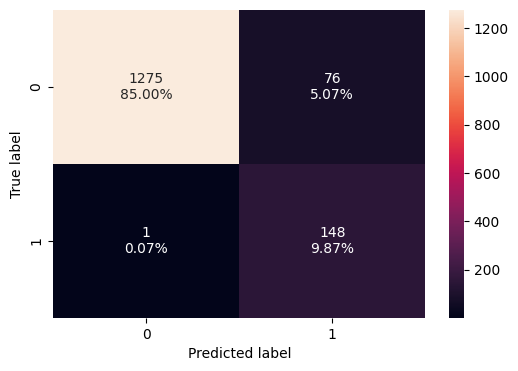

```python
# Confusion matrix on test set
confusion_matrix_sklearn(dt_post_pruned, X_test, y_test)
```

```python
# Model performance on test set
dt_post_pruned_perf_test = model_performance_classification_sklearn(dt_post_pruned, X_test, y_test)
dt_post_pruned_perf_test
```

|  | Accuracy | Recall | Precision | F1 |
| --- | --- | --- | --- | --- |
| 0 | 0.948667 | 0.993289 | 0.660714 | 0.793566 |

#### **Visualize Decision Tree (Post-Pruning)**

```
Decision tree depth: 6
```

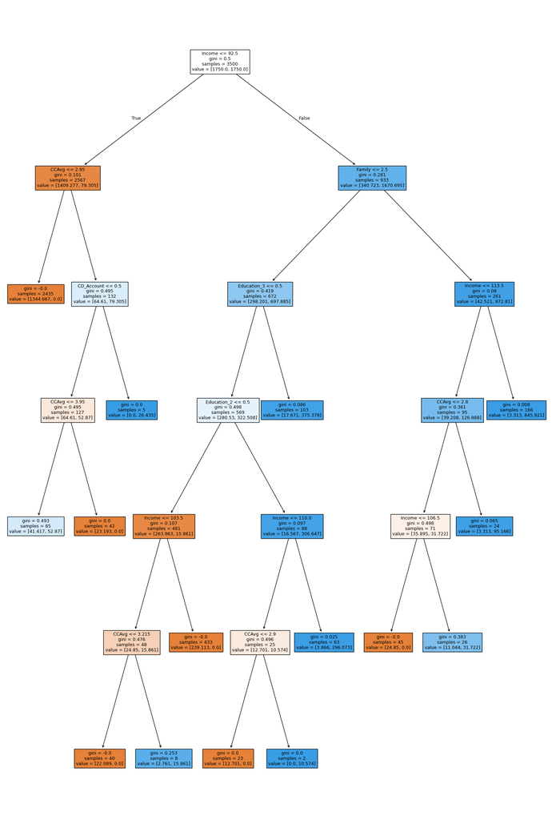

```python
# Display decition tree post-pruning
depth = dt_post_pruned.get_depth()
print(f"Decision tree depth: {depth}")
## Print the decision tree
tree_view(dt_post_pruned,features)
```

```python
# Text report showing the rules of a decision tree -
print(tree.export_text(dt_post_pruned, feature_names=features, show_weights=True))
```

```
|--- Income <= 92.50
|   |--- CCAvg <= 2.95
|   |   |--- weights: [1344.67, 0.00] class: 0
|   |--- CCAvg >  2.95
|   |   |--- CD_Account <= 0.50
|   |   |   |--- CCAvg <= 3.95
|   |   |   |   |--- weights: [41.42, 52.87] class: 1
|   |   |   |--- CCAvg >  3.95
|   |   |   |   |--- weights: [23.19, 0.00] class: 0
|   |   |--- CD_Account >  0.50
|   |   |   |--- weights: [0.00, 26.44] class: 1
|--- Income >  92.50
|   |--- Family <= 2.50
|   |   |--- Education_3 <= 0.50
|   |   |   |--- Education_2 <= 0.50
|   |   |   |   |--- Income <= 103.50
|   |   |   |   |   |--- CCAvg <= 3.21
|   |   |   |   |   |   |--- weights: [22.09, 0.00] class: 0
|   |   |   |   |   |--- CCAvg >  3.21
|   |   |   |   |   |   |--- weights: [2.76, 15.86] class: 1
|   |   |   |   |--- Income >  103.50
|   |   |   |   |   |--- weights: [239.11, 0.00] class: 0
|   |   |   |--- Education_2 >  0.50
|   |   |   |   |--- Income <= 110.00
|   |   |   |   |   |--- CCAvg <= 2.90
|   |   |   |   |   |   |--- weights: [12.70, 0.00] class: 0
|   |   |   |   |   |--- CCAvg >  2.90
|   |   |   |   |   |   |--- weights: [0.00, 10.57] class: 1
|   |   |   |   |--- Income >  110.00
|   |   |   |   |   |--- weights: [3.87, 296.07] class: 1
|   |   |--- Education_3 >  0.50
|   |   |   |--- weights: [17.67, 375.38] class: 1
|   |--- Family >  2.50
|   |   |--- Income <= 113.50
|   |   |   |--- CCAvg <= 2.80
|   |   |   |   |--- Income <= 106.50
|   |   |   |   |   |--- weights: [24.85, 0.00] class: 0
|   |   |   |   |--- Income >  106.50
|   |   |   |   |   |--- weights: [11.04, 31.72] class: 1
|   |   |   |--- CCAvg >  2.80
|   |   |   |   |--- weights: [3.31, 95.17] class: 1
|   |   |--- Income >  113.50
|   |   |   |--- weights: [3.31, 845.92] class: 1
```

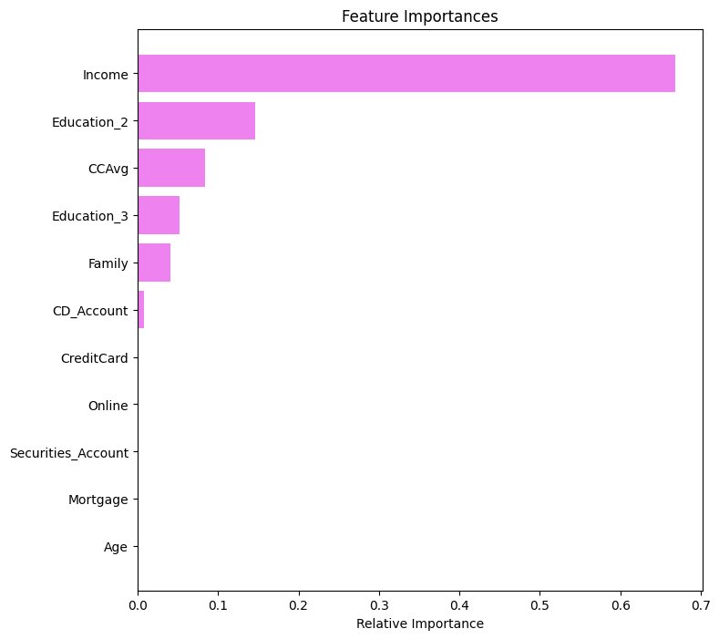

```python
# importance of features in the tree building

importances = dt_post_pruned.feature_importances_
indices = np.argsort(importances)

plt.figure(figsize=(8, 8))
plt.title("Feature Importances")
plt.barh(range(len(indices)), importances[indices], color="violet", align="center")
plt.yticks(range(len(indices)), [features[i] for i in indices])
plt.xlabel("Relative Importance")
plt.show()
```

##### **Model Performance observation**

- The model shows minimal overfitting, with training and test metrics being fairly close
- Very high recall on both sets (100% training, 99.3% test) indicates the model rarely misses positive cases
- Lower precision (~66-69%) suggests some false positives, which is confirmed by the 76 false positives in the confusion matrix
- The model maintains strong overall accuracy (~95%) on both sets
- The F1 scores around 80% balance the trade-off between precision and recall
- The 3 important features are Income, education level (Graduate) and CreditCard spendings

## Model Performance Comparison and Final Model Selection

```python
# training performance comparison

models_train_comp_df = pd.concat(
    [
        dt_defaut_perf_train.T,
        dt_pre_pruned_perf_train.T,
        dt_post_pruned_perf_train.T,
    ],
    axis=1,
)
models_train_comp_df.columns = [
    "Decision Tree (sklearn default)",
    "Decision Tree (Pre-Pruning)",
    "Decision Tree (Post-Pruning)",
]
print("Training performance comparison:")
models_train_comp_df
```

```
Training performance comparison:
```

|  | Decision Tree (sklearn default) | Decision Tree (Pre-Pruning) | Decision Tree (Post-Pruning) |
| --- | --- | --- | --- |
| Accuracy | 1.0 | 0.790286 | 0.956857 |
| Recall | 1.0 | 1.000000 | 1.000000 |
| Precision | 1.0 | 0.310798 | 0.686722 |
| F1 | 1.0 | 0.474212 | 0.814268 |

```python
# testing performance comparison

models_test_comp_df = pd.concat(
    [
        dt_defaut_perf_test.T,
        dt_pre_pruned_perf_test.T,
        dt_post_pruned_perf_test.T,
    ],
    axis=1,
)
models_test_comp_df.columns = [
    "Decision Tree (sklearn default)",
    "Decision Tree (Pre-Pruning)",
    "Decision Tree (Post-Pruning)",
]
print("Testing performance comparison:")
models_test_comp_df
```

```
Testing performance comparison:
```

|  | Decision Tree (sklearn default) | Decision Tree (Pre-Pruning) | Decision Tree (Post-Pruning) |
| --- | --- | --- | --- |
| Accuracy | 0.986667 | 0.779333 | 0.948667 |
| Recall | 0.912752 | 1.000000 | 0.993289 |
| Precision | 0.951049 | 0.310417 | 0.660714 |
| F1 | 0.931507 | 0.473768 | 0.793566 |

**Observation**

**Default Model**

- Perfect scores on all metrics on Taining data. Clear indication of overfitting.
- Strong performance on test data (Accuracy: 0.987 abd F1: 0.932).

**Pre-Pruned Model**

- Has a perfect Recall score on train and test data but poor precision indicates moel is overly aggressive in prediciting possitive class.

**Post-Pruned Model**

- Best balance of metrics among all three models

**Overall**

- Post-pruning achieved the best overall balance of metrics
- Pre-pruning maintained perfect recall but at significant cost to precision
- Default model showed classic overfitting with perfect training scores
- Post-pruning successfully reduced overfitting while maintaining strong performance

**Conclusion**

**The model to adopt is the Post-pruned model.**

## Actionable Insights and Business Recommendations

**Model Recommendation**

We recomment post-pruned model, which would predict which customer would accept the personal loan offer.

*What recommedations would you suggest to the bank?*

From the decision tree model, Income, education, CreditCard spending seems to be the import features. Based on the model analysis and feature importance the following are the recommendation to the bank:

- Income is the most influenctial factor in predicting loan acceptance. Focus marketing efforts on high-income segments.
- Develop income specific loan product and terms.
- Consider income verification as critical part of loan application.
- Consider automated income verification system for efficiency.
- Education is second most impotant preditor, consider developing special loan products for graduate.
- Partner with education institutions for targeted marketing.
- Average credit card spending is also a strong predictor, consider offering combined credid card and personal loan products.
- Less important features (CD_Account, Securities_Account, Mortgage) suggest these products have minimal impact on loan performance, consider bundling products differntly.